# Initial population size and baseline survival

# Preamble

This is an Electronic Supplement to the manuscript Schwacke et al. 2022. Modeling population effects of the Deepwater Horizon oil spill on a long-lived species. $Conservation~Biology$ 36:e13878 DOI: https://doi.org/10.1111/cobi.13878

The master file containing links to all supplementary files related to this paper is BND_Electronic Supplements master file.

If you make use of any of this material in your work, it would be appreciated if you would contact Tiago Marques to let him know.

# Introduction

This document briefly describes the initial population size and the the post oil population averaged survival.

It simply reads in and then displays the distributions that we use as data.

For how these distributions are generated please see the dedicated spatial capture recapture (SCR) study by Glennie et al. 2021. In particular, we considered that the average of the population sizes in primary occasions 6 and 7 were a sensible approximation to the initial population size in April 2010.

# Population size

```r
# Initial population size
Nstart <- read.csv(paste0("InOutBySp/Bottlenose_dolphin_BB/N_boot.csv"), header = TRUE)
Nstart <- Nstart[, 2]
Nstart <- as.vector(Nstart)
```

The mean initial population size considering 10000 available samples from the posterior of the SCR model ranged between 2441 and 23115. The mean population size was 3045 and the median 3001 with a 95% confidence interval of 2720 – 3611. We can plot the distribution of the population size estimates (removing estimates above double the mean for better visualization)

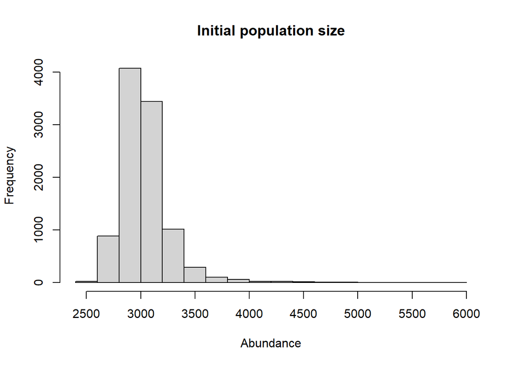

```r
index <- Nstart < 2 * mean(Nstart)
hist(Nstart[index], main = "Initial population size", xlab = "Abundance")
```

# Post-spill survival

```r
SpostOilBB <- read.csv(file = "InOutBySp/Bottlenose_dolphin_BB/PostOilSurv.csv", header = FALSE, col.names = "S")
SpostOilBB <- as.numeric(SpostOilBB$S)
```

The population average survival considering 10000 parametric resamples from the SCR model ranged between 0.571 and 0.944. The mean survival was 0.818 and the median 0.823 with a 95% interval of 0.695 – 0.909. We can plot the distribution of the survival post oil spill estimates

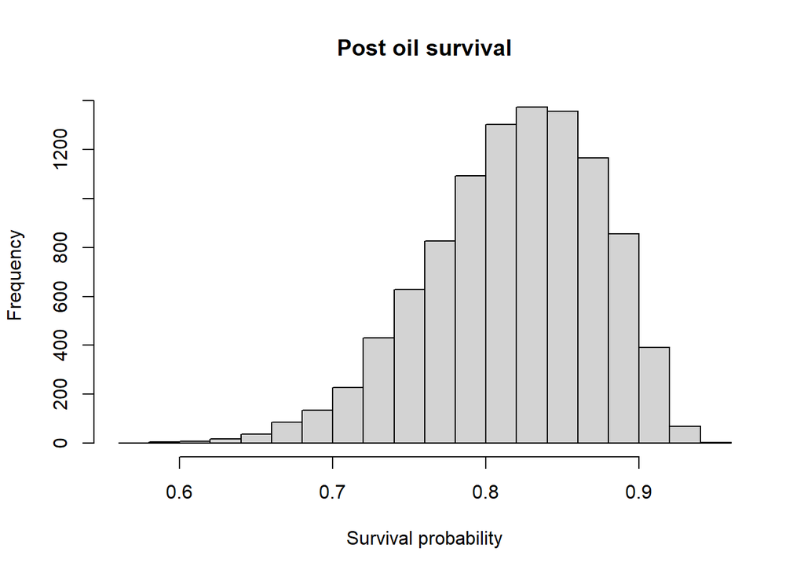

```r
hist(SpostOilBB, main = "Post oil survival", xlab = "Survival probability")
```

# References

Glennie, R.; Thomas, L.; Speakman, T.; Garrison, L.; Takeshita, R. & Schwacke, L. 2021. [Estimating spatially-varying density and time-varying demographics with open population spatial capture-recapture: a photo-ID case study on bottlenose dolphins in Barataria Bay, Louisana, USA](https://arxiv.org/abs/2106.09579) arXiv:2106.09579